# COMPSCIX 415.2 Homework 9/Final

Bryan Hee

April 4, 2018

# Bootstrapping

### Question 1

Loading the Titanic dataset and forcing all character columns to factors. Also forcing the Survived column to a factor:

```r
Titanic_R2 <- read.csv(file = "C:/Users/BryanHee/OneDrive - stok LLC/Intro to Data Science/HW Assignments/Assignment 9/train.csv")

Titanic_R2[,sapply(Titanic_R2, is.character)] <- lapply(Titanic_R2[,sapply(Titanic_R2, is.character)], as.factor)

Titanic_R2$Survived <- factor(Titanic_R2$Survived, ordered = FALSE)
Titanic_R2 %>%
  glimpse()
```

```
## Observations: 891
## Variables: 12
## $ PassengerId <int> 1, 2, 3, 4, 5, 6, 7, 8, 9, 10, 11, 12, 13, 14, 15,...
## $ Survived    <fct> 0, 1, 1, 1, 0, 0, 0, 0, 1, 1, 1, 1, 0, 0, 0, 1, 0,...
## $ Pclass      <int> 3, 1, 3, 1, 3, 3, 1, 3, 3, 2, 3, 1, 3, 3, 3, 2, 3,...
## $ Name        <fct> Braund, Mr. Owen Harris, Cumings, Mrs. John Bradle...
## $ Sex         <fct> male, female, female, female, male, male, male, ma...
## $ Age         <dbl> 22, 38, 26, 35, 35, NA, 54, 2, 27, 14, 4, 58, 20, ...
## $ SibSp       <int> 1, 1, 0, 1, 0, 0, 0, 3, 0, 1, 1, 0, 0, 1, 0, 0, 4,...
## $ Parch       <int> 0, 0, 0, 0, 0, 0, 0, 1, 2, 0, 1, 0, 0, 5, 0, 0, 1,...
## $ Ticket      <fct> A/5 21171, PC 17599, STON/O2. 3101282, 113803, 373...
## $ Fare        <dbl> 7.2500, 71.2833, 7.9250, 53.1000, 8.0500, 8.4583, ...
## $ Cabin       <fct> , C85, , C123, , , E46, , , , G6, C103, , , , , , ...
## $ Embarked    <fct> S, C, S, S, S, Q, S, S, S, C, S, S, S, S, S, S, Q,...
```

### Question 2

Creating a 100 dataset bootstrap:

```r
titanic_boot <- modelr::bootstrap(data = Titanic_R2, n = 100)
is.tibble(titanic_boot)
```

```
## [1] TRUE
```

```r
titanic_boot
```

```
## # A tibble: 100 x 2
##    strap          .id
##    <list>         <chr>
##  1 <S3: resample> 001
##  2 <S3: resample> 002
##  3 <S3: resample> 003
##  4 <S3: resample> 004
##  5 <S3: resample> 005
##  6 <S3: resample> 006
##  7 <S3: resample> 007
##  8 <S3: resample> 008
##  9 <S3: resample> 009
## 10 <S3: resample> 010
## # ... with 90 more rows
```

Verifying that 100 sample sets were created:

```r
titanic_boot$strap[[100]] %>%
  as.tibble() %>%
  glimpse()
```

```
## Observations: 891
## Variables: 12
## $ PassengerId <int> 350, 92, 85, 86, 783, 760, 512, 319, 59, 51, 88, 5...
## $ Survived    <fct> 0, 0, 1, 1, 0, 1, 0, 1, 1, 0, 0, 0, 0, 0, 1, 1, 0,...
## $ Pclass      <int> 3, 3, 2, 3, 1, 1, 3, 1, 2, 3, 3, 3, 1, 3, 3, 3, 2,...
## $ Name        <fct> Dimic, Mr. Jovan, Andreasson, Mr. Paul Edvin, Ilet...
## $ Sex         <fct> male, male, female, female, male, female, male, fe...
## $ Age         <dbl> 42, 20, 17, 33, 29, 33, NA, 31, 5, 7, NA, NA, 71, ...
## $ SibSp       <int> 0, 0, 0, 3, 0, 0, 0, 0, 1, 4, 0, 0, 0, 0, 0, 0, 1,...
## $ Parch       <int> 0, 0, 0, 0, 0, 0, 0, 2, 2, 1, 0, 0, 0, 0, 0, 0, 0,...
## $ Ticket      <fct> 315088, 347466, SO/C 14885, 3101278, 113501, 11015...
## $ Fare        <dbl> 8.6625, 7.8542, 10.5000, 15.8500, 30.0000, 86.5000...
## $ Cabin       <fct> , , , , D6, B77, , C7, , , , , , , , , , , , , , ,...
## $ Embarked    <fct> S, S, S, S, S, S, S, S, S, S, S, Q, C, S, C, S, C,...
```

### Question 3

Taking distinct count of rows in a sample bootstrap datasets and double checking via for loop that the code is accurate:

```r
as.tibble(titanic_boot$strap[[20]]) %>% n_distinct()
```

```
## [1] 556
```

```r
as.tibble(titanic_boot$strap[[40]]) %>% n_distinct()
```

```
## [1] 574
```

```r
as.tibble(titanic_boot$strap[[100]]) %>% n_distinct()
```

```
## [1] 580
```

```r
##double checking the above code is correct
dummy <- c(20, 40, 100)
double_check <- rep(NA, 3)

for(i in 1:3) {
  as.tibble(titanic_boot$strap[[dummy[i]]]) -> holder
  length(unique(holder$PassengerId)) -> double_check[i]
  rm(holder)
}
double_check
```

```
## [1] 556 574 580
```

### Questions 4 & 5

Plotting the bootstrapped average age:

```r
age_mean <- function(dataset) {
  data <- as.tibble(dataset) # convert input data set to a tibble
  mean_age <- mean(data$Age, na.rm = TRUE) # take the mean of Age, remove NAs
  return(mean_age) # return the mean value of Age from data
}


# loop through the 100 bootstrap samples and use the age_mean()
# function
all_means <- rep(NA, 100)

# start the loop
for(i in 1:100) {
  all_means[i] <- age_mean(titanic_boot$strap[[i]])
}

# take a look at some of the means you calculated from your samples
head(all_means)
```

```
## [1] 29.67766 30.44680 29.49863 28.61158 30.38888 29.30680
```

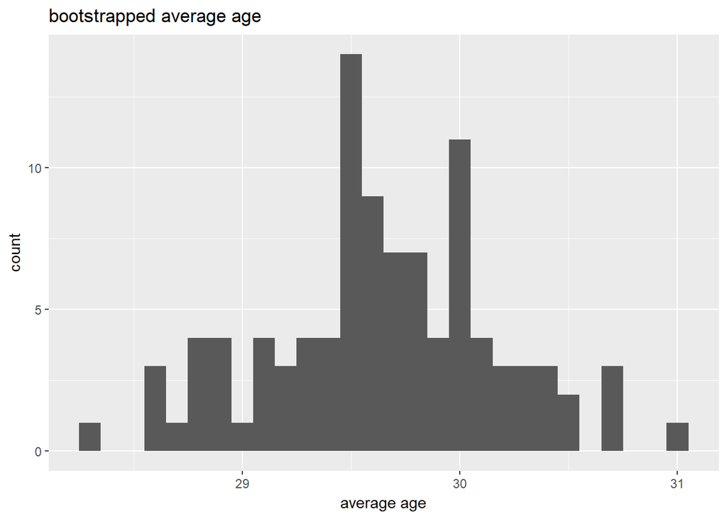

```r
# convert to a tibble so we can use if for plotting
all_means <- tibble(all_means = all_means)

ggplot(all_means) +
  geom_histogram(mapping = aes(x = all_means), binwidth = 0.1) +
  labs(y = "count", x = "average age", title = "bootstrapped average age")
```

Recreating the histogram with different code:

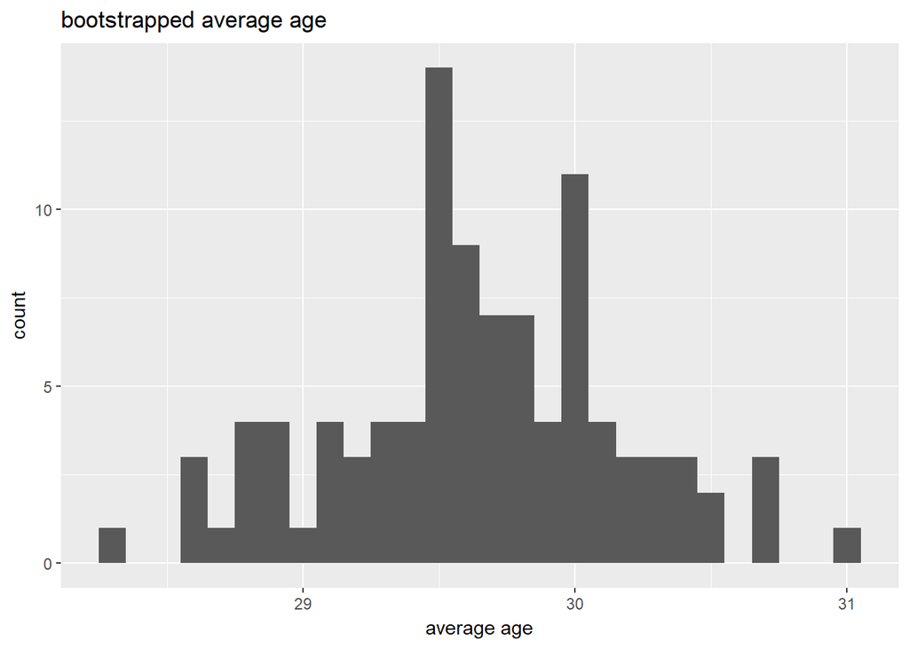

```r
##Alternative way
age_means <- rep(NA, 100)
for(i in 1:100){
  as.tibble(titanic_boot$strap[[i]]) -> holder
  mean(holder$Age, na.rm = TRUE) -> age_means[i]
  rm(holder)
}

age_means <- as.tibble(age_means)

ggplot(data = age_means) +
  geom_histogram(mapping = aes(x = value), binwidth = 0.1) +
  labs(y = "count", x = "average age", title = "bootstrapped average age")
```

### Question 6

The empirical standard error is 3x smaller than the thoeretical standard error.

```r
SE_theory <- sd(Titanic_R2$Age, na.rm = TRUE)/sqrt(as.numeric(count(all_means)))
SE_theory
```

```
## [1] 1.45265
```

```r
SE_empire <- sd(all_means$all_means, na.rm = TRUE)
SE_empire
```

```
## [1] 0.525472
```

# Random Forest

```r
set.seed(987)

model_data <- resample_partition(Titanic_R2, c(test = 0.3, train = 0.7))
train_set <- as.tibble(model_data$train)
test_set <- as.tibble(model_data$test)
```

### Question 2

Compared to last week’s 3-feature tree, this tree has additional nodes and male are split by age. However, for the most part it looks fairl similar. See below for the resultant tree model:

```r
tree_2 <- rpart(Survived ~ Pclass + Sex + Age + SibSp + Parch + Fare + Embarked, data = train_set)
tree_2
```

```
## n= 624
##
## node), split, n, loss, yval, (yprob)
##       * denotes terminal node
##
##   1) root 624 235 0 (0.62339744 0.37660256)
##     2) Sex=male 404  74 0 (0.81683168 0.18316832)
##       4) Age>=6.5 387  61 0 (0.84237726 0.15762274) *
##       5) Age< 6.5 17   4 1 (0.23529412 0.76470588) *
##     3) Sex=female 220  59 1 (0.26818182 0.73181818)
##       6) Pclass>=2.5 97  45 0 (0.53608247 0.46391753)
##        12) Fare>=22.7375 19   1 0 (0.94736842 0.05263158) *
##        13) Fare< 22.7375 78  34 1 (0.43589744 0.56410256)
##          26) Fare>=7.8875 48  22 0 (0.54166667 0.45833333)
##            52) Age>=15.5 40  16 0 (0.60000000 0.40000000)
##             104) Age< 25.5 17   3 0 (0.82352941 0.17647059) *
##             105) Age>=25.5 23  10 1 (0.43478261 0.56521739) *
##            53) Age< 15.5 8   2 1 (0.25000000 0.75000000) *
##          27) Fare< 7.8875 30   8 1 (0.26666667 0.73333333) *
##       7) Pclass< 2.5 123   7 1 (0.05691057 0.94308943) *
```

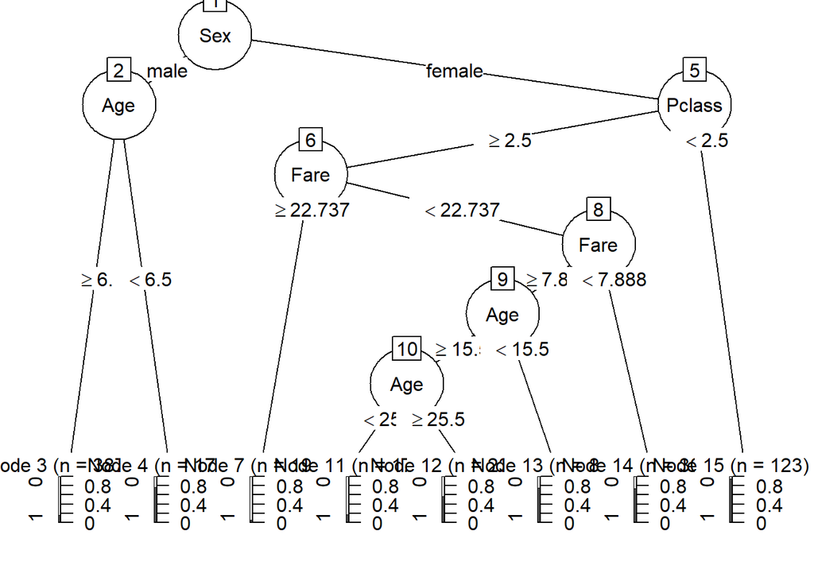

```r
plot(as.party(tree_2))
```

### Question 3

Create a random forest model of the same data:

```r
rf_mod <- randomForest(Survived ~ Pclass + Sex + Age + SibSp + Parch + Fare + Embarked,
                         data = train_set,
                         ntrees = 500,
                         mtry = 4,
                         na.action = na.roughfix)
rf_mod
```

```
##
## Call:
##  randomForest(formula = Survived ~ Pclass + Sex + Age + SibSp +      Parch + Fare + Embarked, data = train_set, ntrees = 500,      mtry = 4, na.action = na.roughfix)
##                Type of random forest: classification
##                      Number of trees: 500
## No. of variables tried at each split: 4
##
##         OOB estimate of  error rate: 17.63%
## Confusion matrix:
##     0   1 class.error
## 0 350  39   0.1002571
## 1  71 164   0.3021277
```

### Question 4

As expected the random forest represents a better fitting model due to the higher AUC.

```r
rf_preds <- predict(rf_mod, newdata = test_set, type = 'prob')[,2]
tree_preds <- predict(tree_2, newdata = test_set)[,2]

pred_rf <- prediction(predictions = rf_preds, labels = test_set$Survived)
pred_tree <- prediction(predictions = tree_preds, labels = test_set$Survived)

auc_rf <- performance(prediction.obj = pred_rf, measure = "auc")
auc_tree <- performance(prediction.obj = pred_tree, measure = "auc")

# extract the AUC value
auc_rf@y.values[[1]]
```

```
## [1] 0.8640449
```

```r
auc_tree@y.values[[1]]
```

```
## [1] 0.7903037
```

### Question 5

Plotting both ROC curves in the same graph:

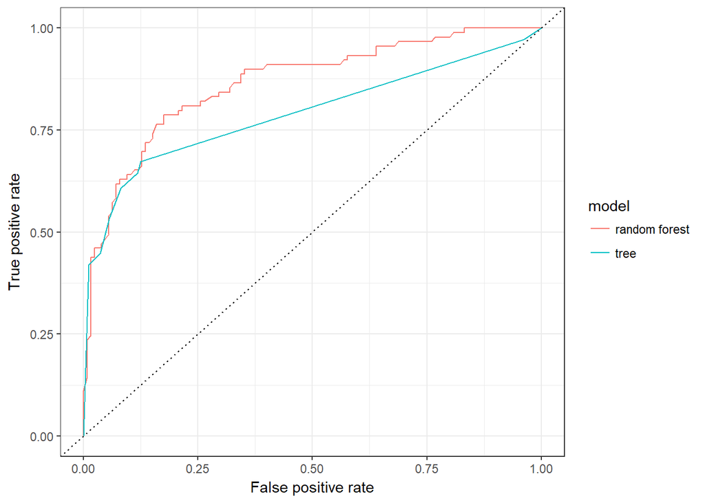

```r
# get the FPR and TPR for the random forest model
perf_rf <- performance(pred_rf, measure = 'tpr', x.measure = 'fpr')
perf_rf_tbl <- tibble(perf_rf@x.values[[1]], perf_rf@y.values[[1]])

perf_rf_tbl[3] <- factor("random forest", ordered = FALSE)
# Change the names of the columns of the tibble
names(perf_rf_tbl) <- c('fpr', 'tpr', 'model')

# get the FPR and TPR for the simple tree model
perf_tree <- performance(pred_tree, measure = 'tpr', x.measure = 'fpr')
perf_tree_tbl <- tibble(perf_tree@x.values[[1]], perf_tree@y.values[[1]])

perf_tree_tbl[3] <- factor("tree", ordered = FALSE)
# Change the names of the columns of the tibble
names(perf_tree_tbl) <- c('fpr', 'tpr', 'model')

#Combine results into one tibble
rf_vs_tree <- bind_rows(perf_rf_tbl, perf_tree_tbl)
rf_vs_tree <- transform(rf_vs_tree, model = as.factor(model))

# Plotting function for plotting a nice ROC curve using ggplot
plot_roc <- function(perf_tbl) {
  p <- ggplot(data = perf_tbl, aes(x = fpr, y = tpr, color = model)) +
  geom_line() +
  geom_abline(intercept = 0, slope = 1, lty = 3) +
  labs(x = 'False positive rate', y = 'True positive rate') +
  theme_bw()
  return(p)
}
plot_roc(rf_vs_tree)
```

### Question 6

Based on the ROC curves, the random forest model performs better. This is because the AUC of the random forest performance (red) is greater than the simple tree model (blue/green).

If we attain a true positive rate of ~0.75, the approximate false positive rate for the random forest model is 0.155, whereas the false positive rate for the simple tree model is 0.34.